# EDS 230: Assignment 04

Andrew Bartnik, Mallory Giesie, Javier Patrón

2023-05-04

# Assignment with LHS

Due date: 2022-04-19

## Sensitivity Analysis

Often when we are estimating vegetation or crop water use we need to know the atmospheric conductance - which is essentially how easily water diffuses into the air and depends largely on wind speed (you get more evaporation in windier conditions) Atmospheric conductance is also influenced by the vegetation itself and the turbulence it creates.

I’ve provided a function to compute atmospheric conductance Cat (how easily vapor diffuses from vegetation surfaces)

The function Catm.R is provided So that you know what it does - here’s some background on the function

$$\text{Cat} = \frac{v}{6.25 \ln \left( \frac{z_m - z_d}{z_0} \right)^2}$$
$${z_d} =k_d \cdot h$$

$${z_d} =k_0 \cdot h$$

- zm = is the height at which windspeed is measured - must be higher than the vegetation (cm), it is usually measured 200 cm above the vegetation
- h is vegetation height (cm)
- v is windspeed (cm/s)
- Typical values if kd and ko are 0.7 and 0.1 respectively (so use those as defaults)

```r
source("/Users/javipatron/Documents/MEDS/Courses/eds230/classes/ESM232_Examples/R/Catm.R")
```

## Your task

For a given forest, you will perform a sensitivity analysis of model predictions of conductance Consider the sensitivity of your estimate to uncertainty in the following parameters and inputs • height • kd • k0 • v

Windspeeds v are normally distributed with a mean of 250 cm/s with a standard deviation of 30 cm/s For vegetation height assume that height is somewhere between 9.5 and 10.5 m (but any value in that range is equally likely).

For the kd and k0 parameters you can assume that they are normally distributed with standard deviation of 1% of their default values.

1. Use the Latin hypercube approach to generate parameter values for the 4 parameters

```r
# which parameters
pnames = c("v", "height", "k_d", "k_o")

# how many parameters
npar =  length(pnames)

# how many samples
nsample = 100


parm_quant = randomLHS(nsample, npar)
colnames(parm_quant) = pnames

# create the empty matrix
parm = as.data.frame(matrix(nrow=nrow(parm_quant),
                            ncol=ncol(parm_quant)))
colnames(parm) = pnames


# to make it easy to change i'm setting standard deviation / range variation to a variable
pvar = 0.01 # 1%

parm[,"v"] = qnorm(parm_quant[,"v"], mean = 250, sd = 30)

# for uniform I'm using +- 10%
parm[,"height"] = qunif(parm_quant[,"height"], min = 9.5, max = 10.5)

parm[,"k_d"] = qnorm(parm_quant[,"k_d"], mean = 0.7, sd = 0.7 * pvar)
parm[,"k_o"] = qnorm(parm_quant[,"k_o"], mean = 0.1, sd = 0.1 * pvar)


X1 <- data.frame(parm)

summary(X1)
```

```
##        v             height            k_d              k_o
##  Min.   :168.2   Min.   : 9.506   Min.   :0.6779   Min.   :0.09758
##  1st Qu.:229.8   1st Qu.: 9.751   1st Qu.:0.6954   1st Qu.:0.09934
##  Median :250.3   Median :10.001   Median :0.7000   Median :0.10001
##  Mean   :250.0   Mean   :10.000   Mean   :0.7000   Mean   :0.10000
##  3rd Qu.:270.1   3rd Qu.:10.249   3rd Qu.:0.7047   3rd Qu.:0.10068
##  Max.   :327.1   Max.   :10.500   Max.   :0.7178   Max.   :0.10247
```

2. Run the atmospheric conductance model for these parameters

```r
# lets now run our model for all of the parameters generated by LHS
# pmap is useful here - it is a map function that uses the actual names of input parameters

atmospheric_values = X1 |> pmap(Catm)

# notice that what pmap returns is a list
head(atmospheric_values)
```

```
## [[1]]
## [1] 1292.295
##
## [[2]]
## [1] 1214.407
##
## [[3]]
## [1] 1423.275
##
## [[4]]
## [1] 1405.038
##
## [[5]]
## [1] 1231.123
##
## [[6]]
## [1] 1520.055
```

```r
# turn results in to a dataframe for easy display/analysis
atmospheric_new = data.frame(Ca = unlist(atmospheric_values))

class(atmospheric_new)
```

```
## [1] "data.frame"
```

3. Plot conductance estimates in a way that accounts for parameter uncertainty

[figure not shown]

```r
# add uncertainty bounds on our estimates

all_atm <- cbind(atmospheric_new, X1)

# add uncertainty bounds on our estimates
tmp = all_atm %>% gather(value = "value", key = "Ca")

ggplot(tmp, aes(Ca, value, fill = Ca)) +
  geom_boxplot(alpha = 0.5) +
  labs(y = "Values per parameter",
       x = "Paremeters") +
  facet_wrap(~ Ca, scales= "free")
```

4. Plot conductance estimates against each of your parameters

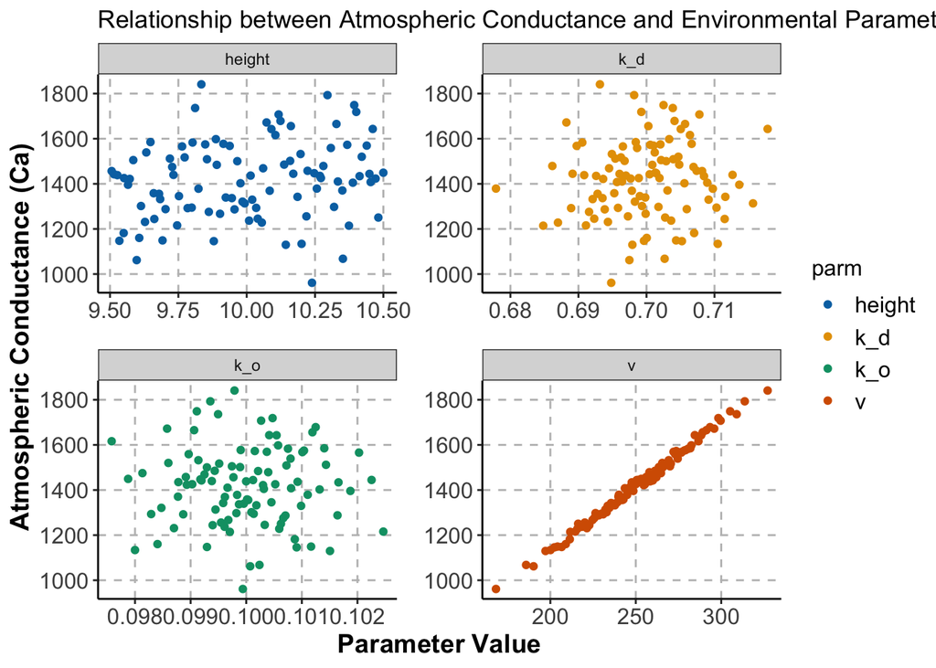

```r
# Doing the pivot longer for the all atmospheric parameters data frame
tmp2 = all_atm %>% gather(Ca, value= "atm_value", key= "atm_con")
tmp3 = tmp2 %>% gather(-atm_value, -atm_con, key= "parm", value = "parmvalue")

# Define a color palette
my_palette <- c("#0072B2", "#E69F00", "#009E73", "#D55E00", "#CC79A7", "#F0E442")

# Create the plot with pretty formatting and colors
ggplot(tmp3, aes(parmvalue, atm_value, color = parm)) +
  geom_point() +
  facet_wrap(~parm, scales = "free") +
  theme_bw() +
  theme(
    axis.line = element_line(),
    panel.grid.major = element_line(colour = "gray", linetype = "dashed"),
    panel.grid.minor = element_blank(),
    panel.border = element_blank(),
    axis.text = element_text(size = 12),
    axis.title = element_text(size = 14, face = "bold"),
    legend.title = element_text(size = 12),
    legend.text = element_text(size = 12),
    legend.position = "right",
    panel.spacing = unit(1, "lines")
  ) +
  scale_color_manual(values = my_palette) +
  labs(
    x = "Parameter Value",
    y = "Atmospheric Conductance (Ca)",
    title = "Relationship between Atmospheric Conductance and Environmental Parameters"
  )
```

5. Estimate the Partial Rank Correlation Coefficients

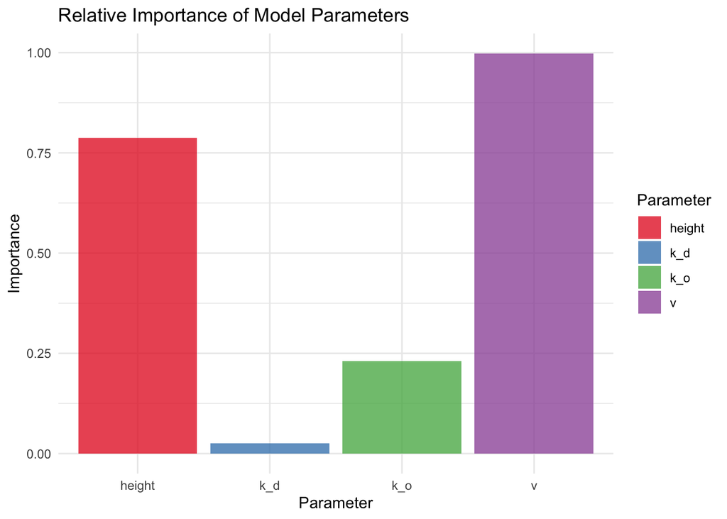

```r
senresult_rank = pcc(X1, atmospheric_new, rank = TRUE)
final_results <- as.data.frame(senresult_rank$PRCC)

# extract the values from the pcc_table object
v <- final_results$original[1]
height <- final_results$original[2]
k_d <- final_results$original[3]
k_o <- final_results$original[4]

# create the data frame
final_df <- data.frame(parameter = c("v", "height", "k_d", "k_o"),
                 importance = c(v, height, k_d, k_o))


# Create the ggplot object
ggplot(final_df, aes(x = parameter, y = importance, fill = parameter)) +
  geom_bar(stat = "identity", alpha = 0.75) +
  scale_fill_brewer(palette = "Set1") +
  labs(title = "Relative Importance of Model Parameters",
       x = "Parameter",
       y = "Importance",
       fill = "Parameter") +
  theme_minimal()
```

```r
kable(final_results,
      caption = "Partial Rank Correlation Coefficients",
      align = "c",
      digits = 5) %>%
    kable_styling(full_width = F, position = "center",
                bootstrap_options = "striped",
                font_size = 16)
```

Partial Rank Correlation Coefficients

|  | original |
| --- | --- |
| v | 0.99796 |
| height | 0.78707 |
| k_d | 0.02505 |
| k_o | 0.23012 |

6. Discuss what your results tell you about how aerodynamic conductance? What does it suggest about what you should focus on if you want to reduce uncertainty in aerodymaic conductance estimates? Does this tell you anything about the sensitivity of plant water use to climate change?

The sensitivity analysis show that aerodynamic conductance is most sensitive to wind speed and vegetation height. We can reduce uncertainty in aerodynamic conductance estimates by improving the measurements of wind speed and vegetation height. With a more unstable climate, extreme weather is likely to cause higher wind speeds - which will likely decrease the amount of water plants can store and use.

Submit the Rmarkdown (or link to git repo) as usual

*Grading Rubric*

*• Generation of parameter values using latin hypercube sampling (10pts)*

*• Running model for the parameters (10pts)*

*• Graph of conductance uncertainty – meaningful graph (5pts) – graphing style (axis labels, legibility) (5 pts)*

*• Graph of conductance against parameter values – meaningful graph (5pts) – graphing style (axis labels, legibility) (5 pts)*

*• Correct Rank Correlation Coefficients (10 pts)*

*• Discussion (10pts) – suggestion for how to reduce uncertainty that follows from your analysis (5pts) – idea about how uncertainty might impact estimate of plant water use under climate change (5pts)*